# QQPlot Notes

The quantile-quantile plot is a commonly used method to visually understand shape of specific measurements and observations.

The central concept is characterizing observations for a given measurement (or variable) based on *quantiles*. To understand *quantile* we must first introduce the notion of an *empirical distribution*.

First, let’s assume we have made $n$ observations of a given variable $x_1,x_2,\ldots,x_n$.

Let’s start simply: the **median** is a value $m$ such that half of the observations are smaller and half of the observations are larger.

Use notation $x_{(1)}$ for smallest, $x_{(2)}$ for second smallest, $x_{(i)}$ for the $i$th ranked observation and $x_{(n)}$ for the largest.

**Question** How would you specify the median using this notation?

We’ll also use the notation $q_{.5}$ for median. Other summaries of interest besides the median are the 1st and 3rd quartiles:

**1st quartile**: $q_{.25}$ value such that 25% of the observations are smaller **3rd quartile**: $q_{.75}$ value such that 75% of the observations are smaller

**Question** How would you specify 1st and 3rd quartiles using the above notation?

The `summary` function we saw in class returns exactly these three values (along with the min and max observations). This is also called the `five number of summary` of a set of observations. We use this summary as part of exploratory analysis to understand the `shape` of a set of observations. E.g., we saw that the boxplot is a graphical display of this summary. A histogram with 4 bins would also correspond to this summary.

The general concept of *quantile* is follows the lines above:

**pth quantile**: $q_p$ value such that $p$ fraction of observations are smaller

```r
library(ggplot2)
data(diamonds)

summary(diamonds$depth)
```

```
##    Min. 1st Qu.  Median    Mean 3rd Qu.    Max.
##   43.00   61.00   61.80   61.75   62.50   79.00
```

```r
qs <- quantile(diamonds$depth, p=c(0,.25,.5,.75,1))
print(qs)
```

```
##   0%  25%  50%  75% 100%
## 43.0 61.0 61.8 62.5 79.0
```

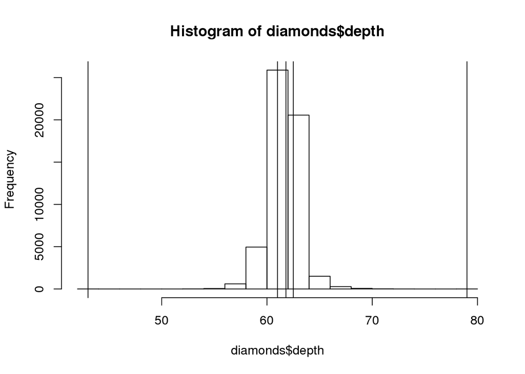

```r
hist(diamonds$depth)
abline(v=qs)
```

While we can use quantile information to start understanding `shape`, e.g., spread, skew, presence of outliers, in a set of observations, these can be hard to interpret. So a technique we try to use in EDA frequently is to compare these summary statistics relative to mathematical constructs we understand. This is were *probability distributions* can be used.

You have very likely looked at some standard probability distributions in previous courses. Two particularly useful ones are the *uniform* distribution and the *standard normal distribution*. We will use these strictly as comparison points to the data we have observed.

Consider the uniform distribution between 0 and 1:

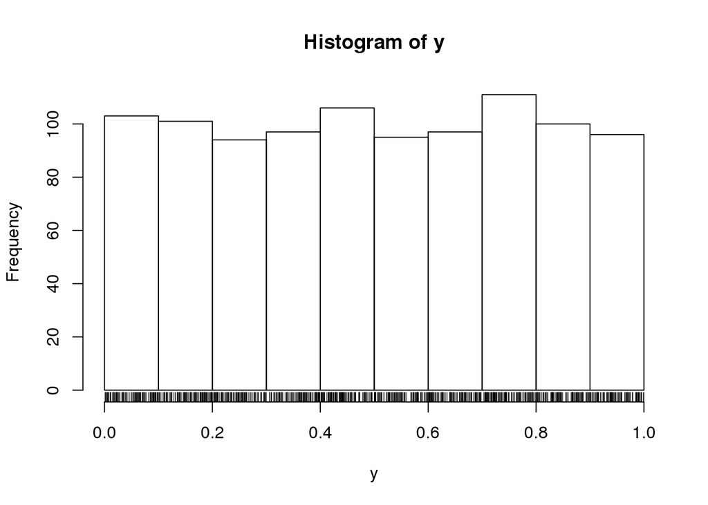

```r
# generate a dataset of 1000 observations from a Uniform(0,1) distribution
y <- runif(1000, min=0, max=1)
hist(y,nc=10)
rug(y)
```

**Question**: What would you expect the median of this dataset to be? **Question**: How about the 1st and 3rd quartiles? **Question**: How about the $p$th quartile?

Using this intuition we can start asking the question, is the `shape` of our set of observations similar to the shape of uniformly distributed data?

From the above discussion, we expect that for $q_p$ for Uniform(a,b) is $a + (b-a) * p$. So we can compare the quantiles of our dataset, to the quantiles we expect to see from uniformly distributed data.

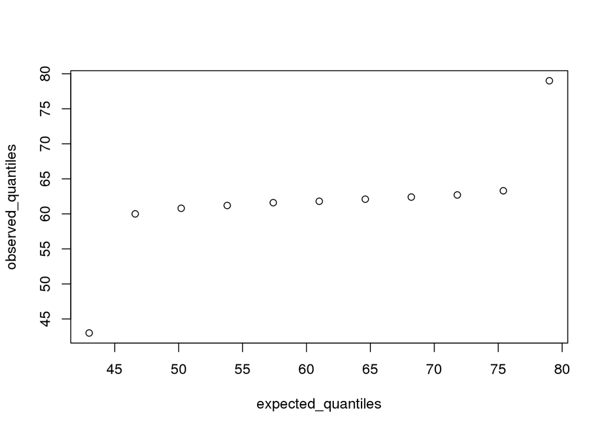

```r
observed_quantiles <- quantile(diamonds$depth, p=seq(0, 1, len=11))
expected_quantiles <- min(diamonds$depth) + (max(diamonds$depth) - min(diamonds$depth)) * seq(0, 1, len=11)
plot(expected_quantiles, observed_quantiles)
```

This is the basis of the quantile-quantile plot:

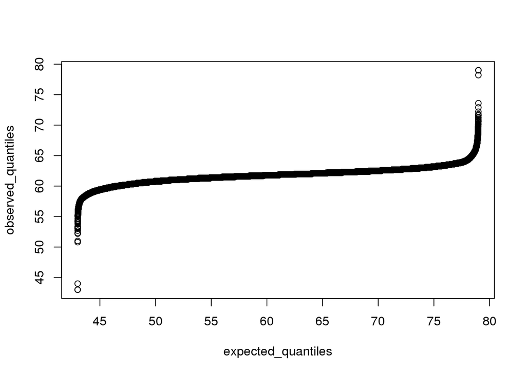

```r
n <- length(diamonds$depth)
observed_quantiles <- sort(diamonds$depth)
expected_quantiles <- min(diamonds$depth) + (max(diamonds$depth) - min(diamonds$depth)) * seq(0, 1, len=n)
plot(expected_quantiles, observed_quantiles)
```

The algorithm to create this plot is:

1. Sort $n$ observations (y axis)
2. Compute $n$ expected quantiles from a reference distribution (x axis)
3. Plot expected vs. observed quantiles

Using a normal distribution:

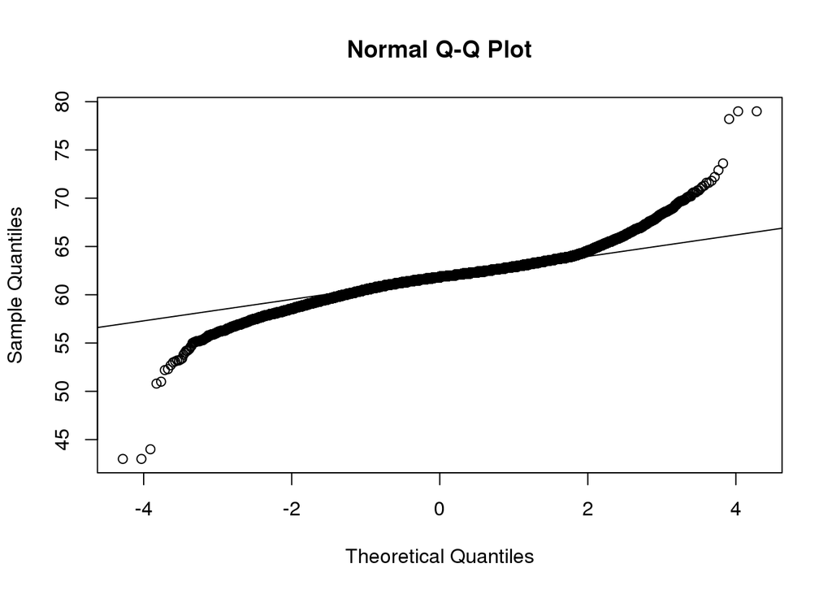

```r
qqnorm(diamonds$depth)
qqline(diamonds$depth)
```

One final note, you can also compare two variables using this tool: instead of computing expected quantiles from a reference distribution mathematicall (analytically) you can compute observed quantiles from a second dataset.

Some questions:

1. If two datasets have the same `shape`, what would the Q-Q plot look like?
2. Consider a car dataset containing two variables: `miles_per_gallon` and `kilometers_per_gallon`. What would the q-q plot look like for the two variables?